# Analyse en Composantes Principales

Jeu de données diecasting

Ce jeu de données contient 211 individus et 19 variables, 11 variables qualitatives sont illustratives.

### 1. Observation d’individus extrêmes

L’analyse des graphes ne révèle aucun individu singulier.

### 2. Distribution de l’inertie

L’inertie des axes factoriels indique d’une part si les variables sont structurées et suggère d’autre part le nombre judicieux de composantes principales à étudier.

Les 2 premiers axes de l’ ACP expriment **52.02%** de l’inertie totale du jeu de données ; cela signifie que 52.02% de la variabilité totale du nuage des individus (ou des variables) est représentée dans ce plan. C’est un pourcentage assez important, et le premier plan représente donc convenablement la variabilité contenue dans une grande part du jeu de données actif. Cette valeur est supérieure à la valeur référence de **32.7%**, la variabilité expliquée par ce plan est donc significative (cette intertie de référence est le quantile 0.95 de la distribution des pourcentages d’inertie obtenus en simulant 1882 jeux de données aléatoires de dimensions comparables sur la base d’une distribution normale).

Du fait de ces observations, il serait tout de même probablement préférable de considérer également dans l’analyse les dimensions supérieures ou égales à la troisième.

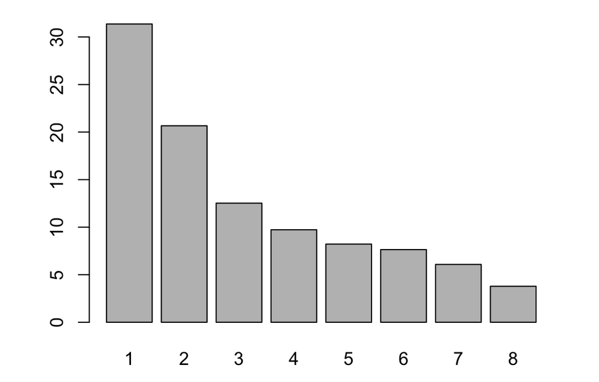

**Figure 2 - Decomposition of the total inertia on the components of the ACP**

Une estimation du nombre pertinent d’axes à interpréter suggère de restreindre l’analyse à la description des 2 premiers axes. Ces composantes révèlent un taux d’inertie supérieur à celle du quantile 0.95 de distributions aléatoires (52.02% contre 32.7%). Cette observation suggère que seuls ces axes sont porteurs d’une véritable information. En conséquence, la description de l’analyse sera restreinte à ces seuls axes.

### 3. Description du plan 1:2

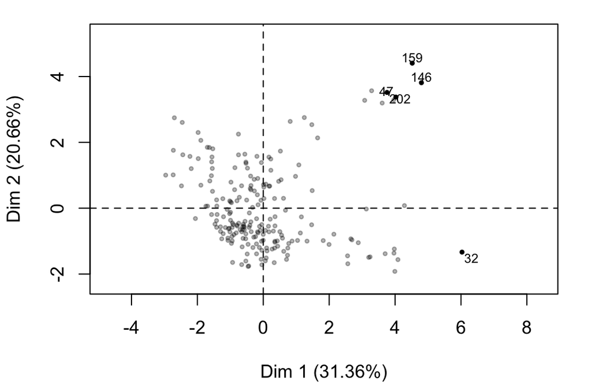

**Figure 3.1 - Graphe des individus (ACP)** *Les individus libellés sont ceux ayant la plus grande contribution à la construction du plan.*

La probabilité critique du test de Wilks indique la variable dont les modalités sépare au mieux les individus sur le plan (i.e. qui explique au mieux les distances entre individus).

```
##     Raw material          Cooling             Date Supplier Country
##     1.586664e-38     6.248816e-15     5.259743e-13     2.061900e-10
##          Process     Over molding         Assembly          idPhoto
##     4.180237e-06     3.444819e-02     1.307511e-01     1.325749e-01
##        Finishing         Supplier
##     2.379819e-01     7.595674e-01
```

La meilleure variable qualitative pour illustrer les distances entre individus sur le plan est la variable : *Raw material*. Les variables qualitatives *ID* ne peuvent séparer les individus sur le plan, car elles sont unimodales.

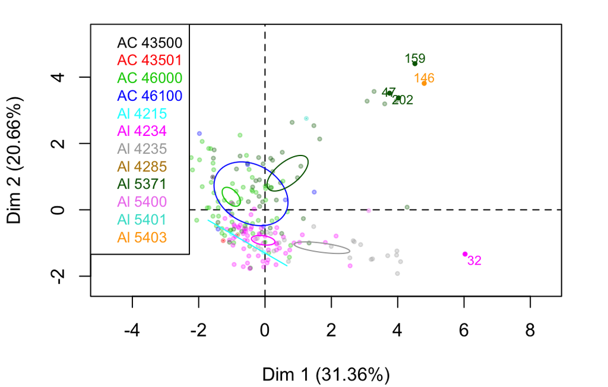

**Figure 3.2 - Graphe des individus (ACP)** *Les individus libellés sont ceux ayant la plus grande contribution à la construction du plan.* *Les individus sont colorés selon leur appartenance aux modalités de la variable* Raw material.

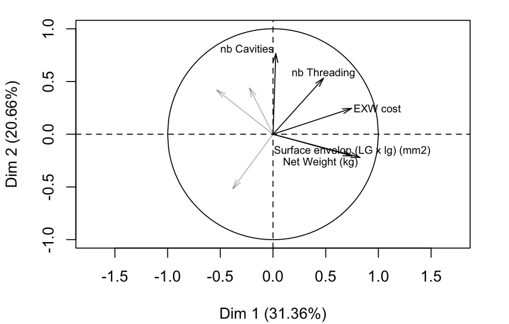

**Figure 3.3 - Graphe des variables (ACP)** *Les variables libellées sont celles les mieux représentées sur le plan.*

[figure not shown]

**Figure 3.4 - Graphe des modalités (ACP)** *Les facteurs libellés sont ceux les mieux représentés sur le plan.*

La **dimension 1** oppose des individus tels que *32*, *159*, *47*, *202* et *146* (à droite du graphe, caractérisés par une coordonnée fortement positive sur l’axe) à des individus caractérisés par une coordonnée fortement négative sur l’axe (à gauche du graphe).

Le groupe auquel les individus *159*, *47*, *202* et *146* appartiennent (caractérisés par une coordonnée positive sur l’axe) partage :

- de fortes valeurs pour les variables *nb.Threading*, *nb.Cavities*, *EXW.cost* et *ID* (de la plus extrême à la moins extrême).
- de faibles valeurs pour la variable *nb.Machining.Surfaces*.

Le groupe auquel l’individu *32* appartient (caractérisés par une coordonnée positive sur l’axe) partage :

- de fortes valeurs pour les variables *Net.Weight.(kg)*, *Surface.envelop.(LG.x.lg).(mm2)*, *EXW.cost* et *ID* (de la plus extrême à la moins extrême).
- de faibles valeurs pour les variables *nb.Cavities*, *Yearly.Volume*, *nb.Machining.Surfaces* et *nb.Cores* (de la plus extrême à la moins extrême).

Le groupe 3 (caractérisés par une coordonnées négative sur l’axe) partage :

- de fortes valeurs pour les variables *Yearly.Volume*, *nb.Cores* et *nb.Cavities* (de la plus extrême à la moins extrême).
- de faibles valeurs pour les variables *ID*, *Surface.envelop.(LG.x.lg).(mm2)*, *Net.Weight.(kg)* et *EXW.cost* (de la plus extrême à la moins extrême).

Le groupe 4 (caractérisés par une coordonnées négative sur l’axe) partage :

- de fortes valeurs pour les variables *nb.Machining.Surfaces* et *ID* (de la plus extrême à la moins extrême).
- de faibles valeurs pour les variables *nb.Cavities*, *EXW.cost*, *nb.Cores*, *Yearly.Volume*, *nb.Threading* et *Net.Weight.(kg)* (de la plus extrême à la moins extrême).

Le groupe 1 (caractérisés par une coordonnée positive sur l’axe) partage :

- de fortes valeurs pour les variables *Yearly.Volume*, *nb.Cores* et *nb.Cavities* (de la plus extrême à la moins extrême).
- de faibles valeurs pour les variables *ID*, *Surface.envelop.(LG.x.lg).(mm2)*, *Net.Weight.(kg)* et *EXW.cost* (de la plus extrême à la moins extrême).

Le groupe auquel les individus *159*, *47*, *202* et *146* appartiennent (caractérisés par une coordonnée positive sur l’axe) partage :

- de fortes valeurs pour les variables *nb.Threading*, *nb.Cavities*, *EXW.cost* et *ID* (de la plus extrême à la moins extrême).
- de faibles valeurs pour la variable *nb.Machining.Surfaces*.

Le groupe 3 (caractérisés par une coordonnées négative sur l’axe) partage :

- de fortes valeurs pour les variables *nb.Machining.Surfaces* et *ID* (de la plus extrême à la moins extrême).
- de faibles valeurs pour les variables *nb.Cavities*, *EXW.cost*, *nb.Cores*, *Yearly.Volume*, *nb.Threading* et *Net.Weight.(kg)* (de la plus extrême à la moins extrême).

Le groupe auquel l’individu *32* appartient (caractérisés par une coordonnées négative sur l’axe) partage :

- de fortes valeurs pour les variables *Net.Weight.(kg)*, *Surface.envelop.(LG.x.lg).(mm2)*, *EXW.cost* et *ID* (de la plus extrême à la moins extrême).
- de faibles valeurs pour les variables *nb.Cavities*, *Yearly.Volume*, *nb.Machining.Surfaces* et *nb.Cores* (de la plus extrême à la moins extrême).

### 4. Classification

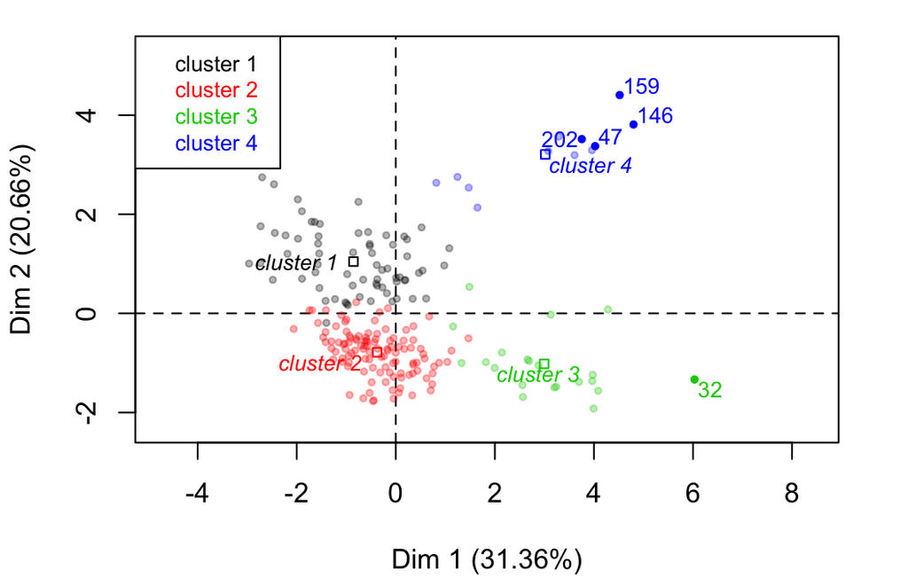

**Figure 4 - Classification Ascendante Hiérachique des individus.** *La classification réalisée sur les individus fait apparaître 4 classes.*

La **classe 1** est composé d’individus partageant :

- de fortes valeurs pour les variables *Yearly.Volume*, *nb.Cores* et *nb.Cavities* (de la plus extrême à la moins extrême).
- de faibles valeurs pour les variables *ID*, *nb.Machining.Surfaces*, *Net.Weight.(kg)*, *Surface.envelop.(LG.x.lg).(mm2)*, *EXW.cost* et *nb.Threading* (de la plus extrême à la moins extrême).

La **classe 2** est composé d’individus partageant :

- de fortes valeurs pour les variables *nb.Machining.Surfaces* et *ID* (de la plus extrême à la moins extrême).
- de faibles valeurs pour les variables *nb.Cavities*, *nb.Cores*, *Yearly.Volume*, *EXW.cost*, *Net.Weight.(kg)*, *nb.Threading* et *Surface.envelop.(LG.x.lg).(mm2)* (de la plus extrême à la moins extrême).

La **classe 3** est composée d’individus tels que *32*. Ce groupe est caractérisé par :

- de fortes valeurs pour les variables *Net.Weight.(kg)*, *Surface.envelop.(LG.x.lg).(mm2)* et *EXW.cost* (de la plus extrême à la moins extrême).
- de faibles valeurs pour les variables *Yearly.Volume*, *nb.Cavities* et *nb.Machining.Surfaces* (de la plus extrême à la moins extrême).

La **classe 4** est composée d’individus tels que *47*, *146*, *159* et *202*. Ce groupe est caractérisé par :

- de fortes valeurs pour les variables *nb.Threading*, *EXW.cost*, *nb.Cavities* et *Surface.envelop.(LG.x.lg).(mm2)* (de la plus extrême à la moins extrême).
- de faibles valeurs pour la variable *nb.Machining.Surfaces*.